Econometrics and Statistics (520K)

# Econometric Methods in Business and Economics

Practical Class (Winter 24/25)

by Domenic Franjic

# Exercise Sheet No 07

Linear Regression with Multiple Regressors (Part 3)

## Set-Up

1) Create your (working) directory

Create a new folder on your computer in which you can save all necessary files, i.e., the data set, the R *script* with the implementation of your analysis and the R *helper function script* with some helper functions provided by us.

This folder, i.e., the path or directory of this folder, will be your so-called working directory.

2) Download the data set

Download the data set `CASchools_03_data.txt` from ILIAS directly or by using the link below:

[Download `CASchools_03_data.txt`](https://ilias.uni-hohenheim.de/goto.php?target=file_1538158_download&client_id=UHOH)

Save the data set into a (working) directory of your choice.

3) Prepare *script*

Open a new R *script* and save it into into your (working) directory.

Run the following code chunk to prepare your R *script*, i.e., to clear the work space and set your working directory.

```r
# Clear workspace
rm(list = ls(all = TRUE))
# Set working directory
setwd(".../set/your/working/directory/...")
```

4) Install/load *packages* and download/save/include *helper function script*

Step 1) Install all relevant R *packages* and download and save the R *script* `r_helper_functions.R` from ILIAS by running the following code chunk.

```r
# Download R-helper functions
source("https://ilias.uni-hohenheim.de/data/UHOH/lm_data/lm_1856939/MA_EconometricMethods_WiSe2324_PracticalClass/r-scripts/prepare_r_packages_and_helper_functions.R")
```

*Note*, the required R *packages* are `"moments"`, `"sandwich"`, `"lmtest"`, `"lmtest"`, `"car"`, `"plm"`, `"ivreg"`, `"dynlm"`, `"forecast"`, `"urca"`.

Step 2) Include the R *script* `r_helper_functions.R` into your R *script* by running the following code chunk.

```r
# Include R-helper functions
source("r_helper_functions.R")
```

*Note*, more information on the helper functions can be found here.

## Task 1

Class size and student performance

We return to our analysis of student performance. For this we use the complete California test score data set`CASchool_03_data.txt` and the two variables $test score$ and the new variable district average income per capita (in 1,000 USD) ($avginc$).

Variables

| Variable | Description |
| --- | --- |
| $students$ | Total enrollment. |
| $teachers$ | Number of teachers. |
| $read$ | Average reading score. |
| $math$ | Average math score. |
| $PctEL$ | Percent of English learners. |
| $Expen$ | Expenditure per student. |
| $avginc$ | Average district income per capita. |

### Task a)

Load the data set into your favorite statistics software and draw a scatter plot of the variables $test score$ and $avginc$. What does the plot suggest regarding the nature of the relationship between $test score$ and $avginc$?

Load data set

```r
# use absolute or relative path to load data
cas.dat <- read.table(file = "CASchools_03_data.txt",
                      header = TRUE,
                      sep = ",")
```

Construct variables

```r
# compute STR and append it to cas.dat
cas.dat$STR <- cas.dat$students/cas.dat$teachers
# compute TestScore and append it to cas.dat
cas.dat$score <- (cas.dat$read + cas.dat$math)/2
```

Scatter plot

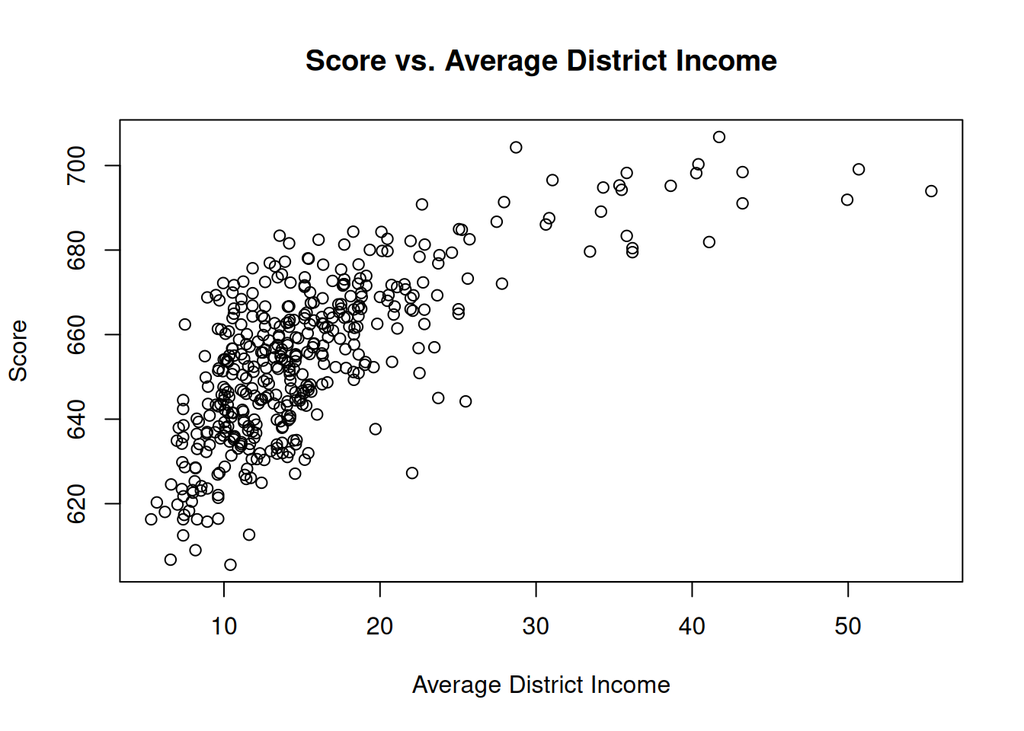

```r
# illustration using a scatterplot
plot(cas.dat$avginc, cas.dat$score,
     xlab = "Average District Income", ylab = "Score",
     main = "Score vs. Average District Income")
```

Interpretation

- The effect of $avinc$ seems to be different for small and large values of $avinc$.
- A linear model is probably inappropriate.
- A polynomial model might be more appropriate.

*Add your results here!*

### Task b)

Estimate a linear, quadratic and a cubic specification between $test score$ and $avginc$ and present your estimation results in tabular form. The results are depicted in the table below. Interpret the estimated regression function for Model 2 and Model 3.

Regression estimation

```r
# model 1
lm.ct.res.01 <- lm_ct_fun(score ~ avginc, data = cas.dat, hc.type = "HC1")
lm.ct.res.01$ct
# model 2
lm.ct.res.02 <- lm_ct_fun(score ~ avginc + I(avginc^2), data = cas.dat, hc.type = "HC1")
lm.ct.res.02$ct
# model 3
lm.ct.res.03 <- lm_ct_fun(score ~ avginc + I(avginc^2) + I(avginc^3), data = cas.dat, hc.type = "HC1")
lm.ct.res.03$ct
```

```
##
## t test of coefficients:
##
##              Estimate Std. Error t value  Pr(>|t|)
## (Intercept) 625.38358    1.86787 334.811 < 2.2e-16 ***
## avginc        1.87855    0.11363  16.532 < 2.2e-16 ***
## ---
## Signif. codes:  0 '***' 0.001 '**' 0.01 '*' 0.05 '.' 0.1 ' ' 1
```

```
##
## t test of coefficients:
##
##                Estimate  Std. Error  t value  Pr(>|t|)
## (Intercept) 607.3017435   2.9017544 209.2878 < 2.2e-16 ***
## avginc        3.8509939   0.2680942  14.3643 < 2.2e-16 ***
## I(avginc^2)  -0.0423084   0.0047803  -8.8505 < 2.2e-16 ***
## ---
## Signif. codes:  0 '***' 0.001 '**' 0.01 '*' 0.05 '.' 0.1 ' ' 1
```

```
##
## t test of coefficients:
##
##                Estimate  Std. Error  t value  Pr(>|t|)
## (Intercept)  6.0008e+02  5.1021e+00 117.6150 < 2.2e-16 ***
## avginc       5.0187e+00  7.0735e-01   7.0950 5.606e-12 ***
## I(avginc^2) -9.5805e-02  2.8954e-02  -3.3089  0.001018 **
## I(avginc^3)  6.8549e-04  3.4706e-04   1.9751  0.048918 *
## ---
## Signif. codes:  0 '***' 0.001 '**' 0.01 '*' 0.05 '.' 0.1 ' ' 1
```

- To add polynomials to the formula of the *function* `lm()` use the `^` operator in conjunction with the *function* `I()`.
- For the specification of the formula for the *function* `lm()` the operators `+`, `-`, `*` and `^` have a non arithmetic interpretation.
- The *function* `I()` ensures that the operators are used as arithmetical operators.

```
##
## ========================================================================
##            Model 1              Model 2              Model 3
## ------------------------------------------------------------------------
## intercept  625.384 (1.868) ***  607.302 (2.902) ***  600.079 (5.102) ***
## avginc^1     1.879 (0.114) ***    3.851 (0.268) ***    5.019 (0.707) ***
## avginc^2                         -0.042 (0.005) ***   -0.096 (0.029) **
## avginc^3                                               0.001 (0.000) *
## ------------------------------------------------------------------------
## R^2          0.508                0.556                0.558
## Adj. R^2     0.506                0.554                0.555
## Num. obs.  420                  420                  420
## SER         13.387               12.724               12.707
## ========================================================================
## *** p < 0.001; ** p < 0.01; * p < 0.05
```

Scatter plot

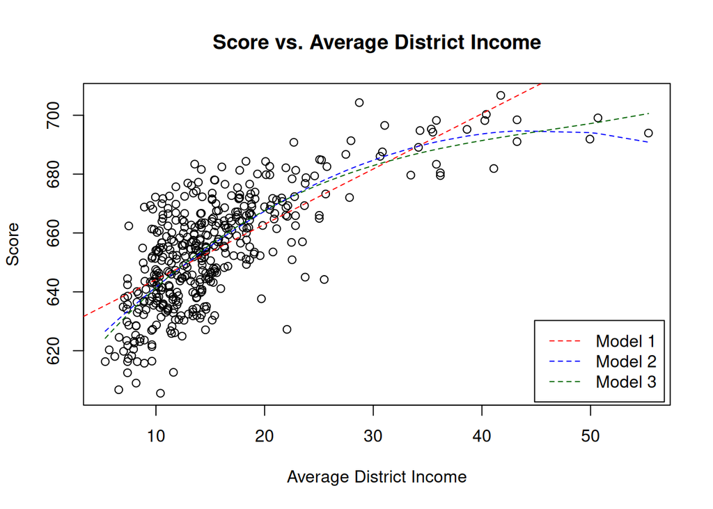

```r
# illustration using a scatterplot and the fitted regression line
plot(cas.dat$avginc, cas.dat$score,
     xlab = "Average District Income", ylab = "Score",
     main = "Score vs. Average District Income")
# order the observations for avginc for the fitted lines of Model 2 and Model 3
order.id <- order(cas.dat$avginc)
# fitted regression line
abline(lm.ct.res.01, lty = 2, col = "red") # model 1
lines(x = cas.dat$avginc[order.id], # model 2
      y = fitted(lm.ct.res.02)[order.id],
      col = "blue",
      lty = 2)
lines(x = cas.dat$avginc[order.id], # model 3
      y = fitted(lm.ct.res.03)[order.id],
      col = "darkgreen",
      lty = 2)
legend("bottomright",
       legend = c("Model 1", "Model 2", "Model 3"),
       col = c("red", "blue", "darkgreen"),
       lty = c(2,2,2),
       inset = 0.01)
```

Interpretation

Specification of the polynomial regression line

Model 1:

$$\begin{align}
Y_i = \beta_0 + \beta_1 X_i
\end{align}$$

Model 2:

$$\begin{align}
Y_i = \beta_0 + \beta_1 X_i + \beta_2 X_i^2
\end{align}$$

Model 3:

$$\begin{align}
Y_i = \beta_0 + \beta_1 X_i + \beta_2 X_i^2 + \beta_3 X_i^3
\end{align}$$

Note, each regression line is linear in its parameters!

*Add your results here!*

### Task c)

Calculate the predicted change in $test score$ for a change in $avginc$ from $5,000 per capita to $6,000 per capita based on Model 2.

Regression results (again)

```
##
## ========================================================================
##            Model 1              Model 2              Model 3
## ------------------------------------------------------------------------
## intercept  625.384 (1.868) ***  607.302 (2.902) ***  600.079 (5.102) ***
## avginc^1     1.879 (0.114) ***    3.851 (0.268) ***    5.019 (0.707) ***
## avginc^2                         -0.042 (0.005) ***   -0.096 (0.029) **
## avginc^3                                               0.001 (0.000) *
## ------------------------------------------------------------------------
## R^2          0.508                0.556                0.558
## Adj. R^2     0.506                0.554                0.555
## Num. obs.  420                  420                  420
## SER         13.387               12.724               12.707
## ========================================================================
## *** p < 0.001; ** p < 0.01; * p < 0.05
```

Calculations

```r
pre.01 <- lm.ct.res.02$ct[1,1] + lm.ct.res.02$ct[2,1]*6 + lm.ct.res.02$ct[3,1]*6^2 -
          (lm.ct.res.02$ct[1,1] + lm.ct.res.02$ct[2,1]*5 + lm.ct.res.02$ct[3,1]*5^2)
pre.01
```

```r
pre.01 <- lm.ct.res.02$ct[1,1] + lm.ct.res.02$ct[2,1]*6 + lm.ct.res.02$ct[3,1]*6^2 -
          (lm.ct.res.02$ct[1,1] + lm.ct.res.02$ct[2,1]*5 + lm.ct.res.02$ct[3,1]*5^2)
pre.01
```

```
## [1] 3.385601
```

Interpretation

$$\begin{align}
\Delta \widehat{test score} &= 607.302 + \left( 3.851 \right) \times
6 + \left( -0.042 \right) \times 6^2 \\
&- \left( 607.302 + \left( 3.851 \right)
\times 5 + \left( -0.042 \right) \times 5^2 \right) \\
&= 3.386
\end{align}$$

*Add your results here!*

### Task d)

Test the null hypothesis of linearity, i.e. Model 1, against the alternative that the population regression is quadratic (Model 2) and/or cubic (Model 3). Use and interpret the results.

Test

```r
library("car")
# heteroskedasticity-robust F-test
lin.hyp.01 <- linearHypothesis(lm.ct.res.03, c("I(avginc^2)=0",
                                               "I(avginc^3)=0"), white.adjust = "hc1")
lin.hyp.01
```

```r
library("car")
# heteroskedasticity-robust F-test
lin.hyp.01 <- linearHypothesis(lm.ct.res.03, c("I(avginc^2)=0",
                                               "I(avginc^3)=0"), white.adjust = "hc1")
lin.hyp.01
```

```
## Linear hypothesis test
##
## Hypothesis:
## I(avginc^2) = 0
## I(avginc^3) = 0
##
## Model 1: restricted model
## Model 2: score ~ avginc + I(avginc^2) + I(avginc^3)
##
## Note: Coefficient covariance matrix supplied.
##
##   Res.Df Df      F    Pr(>F)
## 1    418
## 2    416  2 37.691 9.043e-16 ***
## ---
## Signif. codes:  0 '***' 0.001 '**' 0.01 '*' 0.05 '.' 0.1 ' ' 1
```

Hypothesis

$$\begin{align}
H_0&: \quad \beta_{avinc^2} = \beta_{avinc^3} = 0 \quad \text{vs.}
\\
H_1&: \quad \text{at least one} \neq 0 \quad \quad \quad \alpha =
5\%
\end{align}$$

*Add the hypothesis here!*

Test statistic

$$\begin{align}
F^{act}\left( 2, 416 \right) &= 37.691
\end{align}$$

*Add the test statistic here!*

$p$-value

$$\begin{align}
p-\text{value} &= Pr\left[ F\left( 2, 416 \right) > F^{act}\left(
2, 416 \right) \right] \\
p-\text{value} &= 9.0432\times 10^{-16}
\end{align}$$

*Add the $p$-value here!*

Decision

$$\begin{align}
F^{act}\left( 2, \infty \right) &> F^{crit \, 5\%}\left( 2,
\infty \right) \\
F^{act}\left( 2, \infty \right) &> 3.00
\end{align}$$

- Or, rejection of $H_0$ as $p-\text{value} < 0.05$.

Rejection of $H_0$ as $p-\text{value} < 0.05$.

*Add the decision here!*

Note

- Check also the asymptotic critical value of the test statistic, i,e, $F\left(2,\infty\right)$, for $\alpha =5\%$.
- Use Table 4 in Stock and Watson (2020) on p. 767. (see below)

Critical value for the asymptotic F-distribution

[figure not shown]

Source: Stock and Watson (2020) on p. 767

### Task e)

Estimate a linear-log model for $test score$ and $avginc$ and interpret the slope coefficient. Use the results depicted in Table 3 of the exercise sheet. Add the fitted regression line of the linear-log model to the scatter plot of Task 1a) and compare it with the fitted regression line of the cubic model.

Regression estimation

```r
# model 4
lm.ct.res.04 <- lm_ct_fun(score ~ log(avginc), data = cas.dat, hc.type = "HC1")
lm.ct.res.04$ct
```

```
##
## t test of coefficients:
##
##             Estimate Std. Error t value  Pr(>|t|)
## (Intercept) 557.8323     3.8399 145.271 < 2.2e-16 ***
## log(avginc)  36.4197     1.3969  26.071 < 2.2e-16 ***
## ---
## Signif. codes:  0 '***' 0.001 '**' 0.01 '*' 0.05 '.' 0.1 ' ' 1
```

```
##
## ============================
##              Model 4
## ----------------------------
## Intercept    557.832 (3.840)
## log(avginc)   36.420 (1.397)
## ----------------------------
## R^2            0.563
## Adj. R^2       0.561
## Num. obs.    420
## SER           12.618
## ============================
```

Remember

Remember from calculus

$$\begin{align}
ln\left(x+\Delta x\right) - ln\left(x\right) \cong \frac{\Delta x}{x}
\quad \text{when } \frac{\Delta x}{x} \text{ is small}
\end{align}$$

Specification

$$\begin{align}
Y_i = \beta_0 + \beta_1 ln\left(X_i\right)
\end{align}$$

Note, again, the regression line is linear in its parameters!

$\Delta Y$ w.r.t. $\Delta X$

$$\begin{align}
\Big[Y+\Delta Y\Big] - \Big[Y\Big]&=
\Big[\beta_0+\beta_1 ln\left(X+\Delta X\right)\Big] -
\Big[\beta_0+\beta_1 ln\left(X\right)\Big] \\
\Delta Y &=
\beta_1\Big[ln\left(X+\Delta X\right)-ln\left(X\right)\Big] \\
\Delta Y &\cong \, \beta_1\frac{\Delta X}{X} \quad
\text{(approximately)} \\
\end{align}$$

$\Rightarrow$ A $1\%$ change in $X$ is associated with a change in $Y$ of $0.01\beta_1$.

A $1\%$ change in $avginc$ (in thousand per capita) is associated with an increase in the test score by $0.364$.

*Add your results here!*

Scatter plot

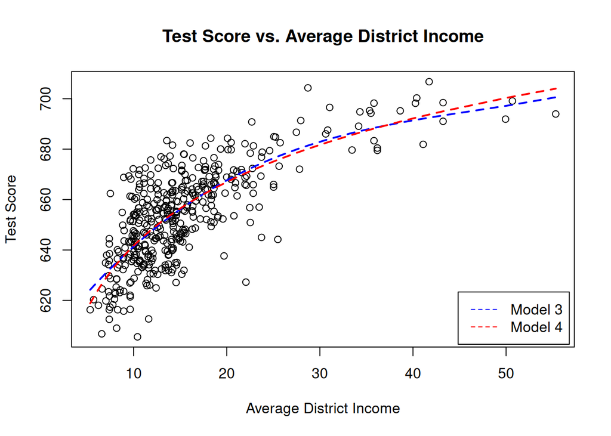

```r
# Illustration using a scatterplot and the fitted regression line
plot(cas.dat$avginc, cas.dat$score,
     xlab = "Average District Income", ylab = "Test Score",
     main = "Test Score vs. Average District Income")
# Order the observations for avginc for the fitted lines
order.id <- order(cas.dat$avginc)
# Fitted regression line
lines(x = cas.dat$avginc[order.id], # Cubic model
      y = fitted(lm.ct.res.03)[order.id],
      col = "blue",
      lty = 2, lwd = 2)
lines(x = cas.dat$avginc[order.id], # lin-log model
      y = fitted(lm.ct.res.04)[order.id],
      col = "red",
      lty = 2, lwd = 2)
legend("bottomright",
       legend = c("Model 3", "Model 4"),
       col = c("blue", "red"),
       lty = c(2,2),
       inset = 0.01)
```

Interpretation

- The fitted regression function of the polynomial and the lin-log model are quite similar.
- The $\overline{R^2}$ of the lin-log model is slightly higher.

*Add your results here!*

### Task f)

Estimate a log-linear and a log-log model for $test score$ and $avginc$ and interpret the slope coefficient. Use the results depicted in Table 3 of the exercise sheet. Compare the regression lines of the two models in a scatter plot of the variables $log\left(test score\right)$ and $avginc$.

Regression estimation

```r
# model 5
lm.ct.res.05 <- lm_ct_fun(log(score) ~ avginc, data = cas.dat, hc.type = "HC1")
lm.ct.res.05$ct
# model 6
lm.ct.res.06 <- lm_ct_fun(log(score) ~ log(avginc), data = cas.dat, hc.type = "HC1")
lm.ct.res.06$ct
```

```
##
## t test of coefficients:
##
##               Estimate Std. Error  t value  Pr(>|t|)
## (Intercept) 6.43936234 0.00289382 2225.210 < 2.2e-16 ***
## avginc      0.00284407 0.00017509   16.244 < 2.2e-16 ***
## ---
## Signif. codes:  0 '***' 0.001 '**' 0.01 '*' 0.05 '.' 0.1 ' ' 1
```

```
##
## t test of coefficients:
##
##              Estimate Std. Error  t value  Pr(>|t|)
## (Intercept) 6.3363494  0.0059246 1069.501 < 2.2e-16 ***
## log(avginc) 0.0554190  0.0021446   25.841 < 2.2e-16 ***
## ---
## Signif. codes:  0 '***' 0.001 '**' 0.01 '*' 0.05 '.' 0.1 ' ' 1
```

```
##
## ================================================================
##              Model 4          Model 5 (log(y))  Model 6 (log(y))
## ----------------------------------------------------------------
## Intercept    557.832 (3.840)    6.439 (0.003)     6.336 (0.006)
## log(avginc)   36.420 (1.397)                      0.055 (0.002)
## avginc                          0.003 (0.000)
## ----------------------------------------------------------------
## R^2            0.563            0.498             0.558
## Adj. R^2       0.561            0.497             0.557
## Num. obs.    420              420               420
## SER           12.618            0.021             0.019
## ================================================================
```

Remember

Log-linear model

$$\begin{align}
ln\left(Y_i\right) = \beta_0 + \beta_1 X_i
\end{align}$$

Log-log model

$$\begin{align}
ln\left(Y_i\right) = \beta_0 + \beta_1 ln\left(X_i\right)
\end{align}$$

Note, each regression line is linear in its parameters!

Log-linear model

$\Delta Y$ w.r.t. $\Delta X$

$$\begin{align}
\Big[ln\left(Y+\Delta Y\right)\Big]-\Big[ln\left(Y\right)\Big]
&= \Big[\beta_0+\beta_1 \left(X+\Delta X\right)\Big] -
\Big[\beta_0+\beta_1 X\Big] \\
ln\left(Y+\Delta Y\right)-ln\left(Y\right) &= \beta_1 \Delta X \\
\frac{\Delta Y}{Y} &\cong \beta_1 \Delta X \quad
\text{(approximately)} \\
\end{align}$$

$\Rightarrow$ A change in $X$ by one unit $\left(\Delta X=1\right)$ is associated with a $100\beta_1\%$ change in $Y$.

Log-log model

$\Delta Y$ w.r.t. $\Delta X$

$$\begin{align}
\Big[ln\left(Y+\Delta Y\right)\Big]-\Big[ln\left(Y\right)\Big] &=
\Big[\beta_0+\beta_1 ln\left(X+\Delta X\right)\Big] -
\Big[\beta_0+\beta_1 ln\left(X\right)\Big] \\
ln\left(Y+\Delta Y\right)-ln\left(Y\right) &= \beta_1
\Big[ln\left(X+\Delta X\right)-ln\left(X\right) \Big]\\
\frac{\Delta Y}{Y} &\cong \beta_1 \frac{\Delta X}{X} \quad
\text{(approximately)} \\
\end{align}$$

$\Rightarrow$ A $1\%$ change in $X$ is associated with a $\beta_1\%$ change in $Y$, so $\beta_1$ is the elasticity of $Y$ with respect to $X$.

- Log-lin model: A $1$ unit change in $avginc$ (in thousand per capita), i.e., one thousand USD, is associated with an increase in the test score by $0.3\%$.
- Log-log model: A $1\%$ change in $avginc$ (in thousand per capita) is associated with an increase in the test score by $0.055\%$.

*Add your results here!*

Scatter plot

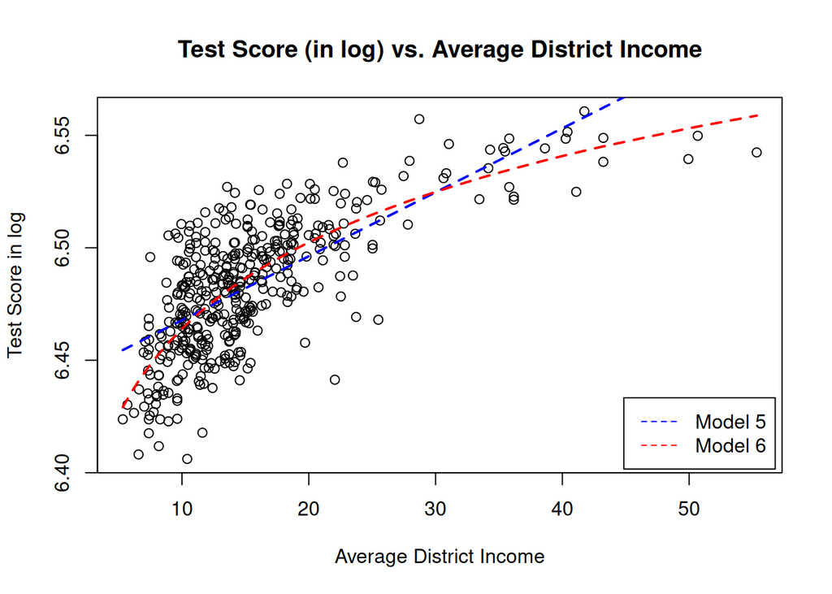

```r
# illustration using a scatterplot and the fitted regression line
plot(cas.dat$avginc, log(cas.dat$score),
     xlab = "Average District Income", ylab = "Test Score in log",
     main = "Test Score (in log) vs. Average District Income")
# order the observations for avginc for the fitted lines
order.id <- order(cas.dat$avginc)
# fitted regression line
lines(x = cas.dat$avginc[order.id], # log-lin model
      y = fitted(lm.ct.res.05)[order.id],
      col = "blue",
      lty = 2, lwd = 2)
lines(x = cas.dat$avginc[order.id], # log-log model
      y = fitted(lm.ct.res.06)[order.id],
      col = "red",
      lty = 2, lwd = 2)
legend("bottomright",
       legend = c("Model 5", "Model 6"),
       col = c("blue", "red"),
       lty = c(2,2),
       inset = 0.01)
```

- The fitted regression function of the log-log specification is better than of the log-linear specification.
- The $\overline{R^2}$ of the log-log model is also higher.
- Important: $R^2$ or $\overline{R^2}$ cannot be used to decide on Model 1 - Model 4 vs. Model 5 - 6!

*Add your results here!*

Back To *Start*